# Experiment outcomes

Erik Ø. Sørensen

16 januar, 2026

# Histogram of distributions

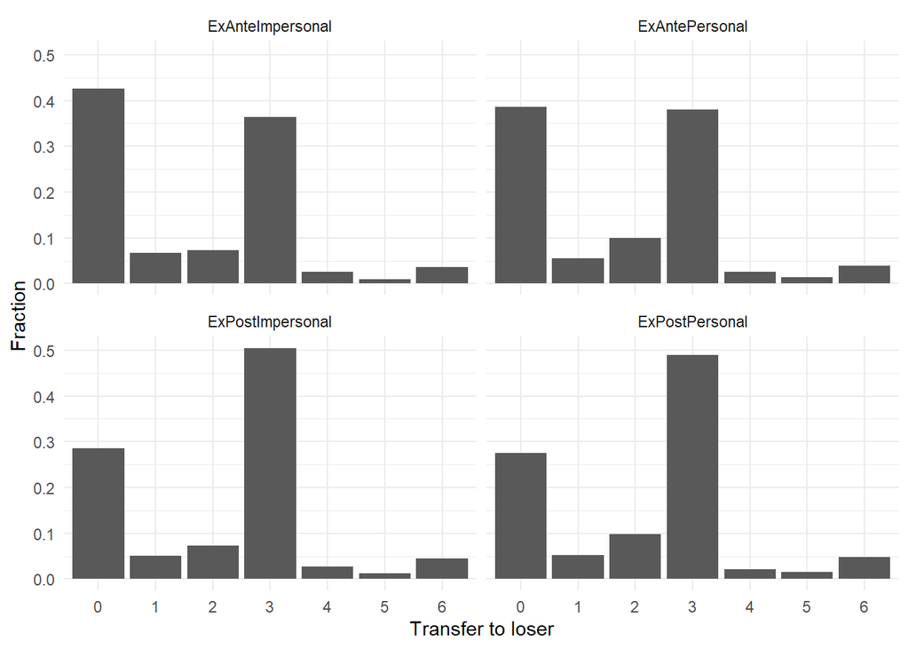

Average transfers:

```r
mean(mmtalent$payment_low_worker-2)
```

```
## [1] 1.970515
```

Modal choice pooled across treatments:

```r
mmtalent %>%
  mutate(transfer = payment_low_worker-2) |>
  group_by(transfer) %>%
  summarise(weighted_count = sum(wgt), .groups = "drop") %>%
  mutate(prop = weighted_count / sum(weighted_count)) |>
  dplyr::select(c(transfer,prop)) |>
  gt() |>
  fmt_number(decimals = 3, columns = 2)
```

| Decision: payment to ind with initial low earnings (USD) | prop |
| --- | --- |
| 0 | 0.342 |
| 1 | 0.056 |
| 2 | 0.086 |
| 3 | 0.436 |
| 4 | 0.025 |
| 5 | 0.013 |
| 6 | 0.042 |

Choice proportions by treatment:

```r
mmtalent %>%
  mutate(transfer = payment_low_worker-2) |>
  group_by(treatment, transfer) %>%
  summarise(weighted_count = sum(wgt)) %>%
  mutate(prop = weighted_count / sum(weighted_count)) |>
  dplyr::select(c(treatment,transfer,prop)) |>
  pivot_wider(
    names_from = treatment,
    values_from = prop
  ) |>
  gt() |>
  fmt_number(decimals = 3, columns = 2:5)
```

| Decision: payment to ind with initial low earnings (USD) | ExPostImpersonal | ExAnteImpersonal | ExAntePersonal | ExPostPersonal |
| --- | --- | --- | --- | --- |
| 0 | 0.286 | 0.426 | 0.386 | 0.275 |
| 1 | 0.051 | 0.067 | 0.055 | 0.052 |
| 2 | 0.073 | 0.073 | 0.100 | 0.099 |
| 3 | 0.505 | 0.364 | 0.381 | 0.490 |
| 4 | 0.027 | 0.025 | 0.026 | 0.021 |
| 5 | 0.012 | 0.010 | 0.013 | 0.016 |
| 6 | 0.045 | 0.036 | 0.039 | 0.047 |

Means broken down by personal.

```
## # A tibble: 2 × 3
##   personal   meanGINI share_nothingtw
##   <fct>         <dbl>           <dbl>
## 1 Impersonal    0.285           0.392
## 2 Personal      0.278           0.374
```

```
##
## Call:
## lm(formula = gini ~ personal, data = mmtalent, weights = wgt)
##
## Weighted Residuals:
##     Min      1Q  Median      3Q     Max
## -0.5739 -0.2411 -0.0721  0.2653  0.6533
##
## Coefficients:
##                   Estimate Std. Error t value Pr(>|t|)
## (Intercept)       0.285332   0.008726  32.700   <2e-16 ***
## personalPersonal -0.010155   0.012266  -0.828    0.408
## ---
## Signif. codes:  0 '***' 0.001 '**' 0.01 '*' 0.05 '.' 0.1 ' ' 1
##
## Residual standard error: 0.2743 on 1999 degrees of freedom
## Multiple R-squared:  0.0003428,  Adjusted R-squared:  -0.0001573
## F-statistic: 0.6854 on 1 and 1999 DF,  p-value: 0.4078
```

```
##
## Call:
## lm(formula = nothingtw ~ personal, data = mmtalent, weights = wgt)
##
## Weighted Residuals:
##     Min      1Q  Median      3Q     Max
## -0.7965 -0.3893 -0.2810  0.5092  1.2625
##
## Coefficients:
##                  Estimate Std. Error t value Pr(>|t|)
## (Intercept)       0.39601    0.01547  25.593   <2e-16 ***
## personalPersonal -0.02366    0.02175  -1.088    0.277
## ---
## Signif. codes:  0 '***' 0.001 '**' 0.01 '*' 0.05 '.' 0.1 ' ' 1
##
## Residual standard error: 0.4865 on 1999 degrees of freedom
## Multiple R-squared:  0.0005916,  Adjusted R-squared:  9.165e-05
## F-statistic: 1.183 on 1 and 1999 DF,  p-value: 0.2768
```

```r
mmtalent |> lm(gini ~ timing*personal, weights=wgt, data=_) |>summary()
```

```
##
## Call:
## lm(formula = gini ~ timing * personal, data = mmtalent, weights = wgt)
##
## Weighted Residuals:
##      Min       1Q   Median       3Q      Max
## -0.65820 -0.24143 -0.05029  0.25788  0.71585
##
## Coefficients:
##                                Estimate Std. Error t value Pr(>|t|)
## (Intercept)                    0.244101   0.012185  20.033  < 2e-16 ***
## timingExAnte                   0.083136   0.017302   4.805 1.66e-06 ***
## personalPersonal               0.000134   0.017075   0.008    0.994
## timingExAnte:personalPersonal -0.019922   0.024324  -0.819    0.413
## ---
## Signif. codes:  0 '***' 0.001 '**' 0.01 '*' 0.05 '.' 0.1 ' ' 1
##
## Residual standard error: 0.272 on 1997 degrees of freedom
## Multiple R-squared:  0.01841,    Adjusted R-squared:  0.01694
## F-statistic: 12.48 on 3 and 1997 DF,  p-value: 4.346e-08
```

```r
mmtalent |> lm(nothingtw ~ timing*personal, weights=wgt, data=_) |>summary()
```

```
##
## Call:
## lm(formula = nothingtw ~ timing * personal, data = mmtalent,
##     weights = wgt)
##
## Weighted Residuals:
##     Min      1Q  Median      3Q     Max
## -0.9294 -0.3670 -0.2720  0.5016  1.3456
##
## Coefficients:
##                                Estimate Std. Error t value Pr(>|t|)
## (Intercept)                    0.331020   0.021646  15.293  < 2e-16 ***
## timingExAnte                   0.131036   0.030736   4.263 2.11e-05 ***
## personalPersonal              -0.009091   0.030332  -0.300    0.764
## timingExAnte:personalPersonal -0.028036   0.043210  -0.649    0.517
## ---
## Signif. codes:  0 '***' 0.001 '**' 0.01 '*' 0.05 '.' 0.1 ' ' 1
##
## Residual standard error: 0.4831 on 1997 degrees of freedom
## Multiple R-squared:  0.01523,    Adjusted R-squared:  0.01375
## F-statistic: 10.29 on 3 and 1997 DF,  p-value: 1.008e-06
```

# Regressions

We look at three different outcomes. The first is the gini coefficient, which (as before) is between 0 and 0.6 (there is a base income of (2,2) that cannot be lowered, so max inequality is (8,2) or (2,8)). The second outcome is a dummy indicator for maximum inequality. The third outcome is no redistribution (so the allocation will remain (8,2).

|  | Gini (1) | Gini (2) | Nothing to worst of (3) | Nothing to worst of (4) | No redistribution (5) | No redistribution (6) |
| --- | --- | --- | --- | --- | --- | --- |
| Ex Ante Personal (d) | 0.063*** | 0.064*** | 0.094*** | 0.100*** | 0.100*** | 0.106*** |
|  | (0.017) | (0.017) | (0.031) | (0.031) | (0.030) | (0.030) |
| Ex Ante Impersonal (d) | 0.083*** | 0.085*** | 0.131*** | 0.133*** | 0.140*** | 0.143*** |
|  | (0.017) | (0.017) | (0.031) | (0.031) | (0.030) | (0.030) |
| Ex Post Personal (d) | 0.000 | 0.001 | -0.009 | -0.007 | -0.011 | -0.008 |
|  | (0.017) | (0.017) | (0.030) | (0.030) | (0.030) | (0.029) |
| High age (d) |  | -0.011 |  | 0.055** |  | 0.074*** |
|  |  | (0.012) |  | (0.022) |  | (0.021) |
| Left (d) |  | -0.049*** |  | -0.093*** |  | -0.076*** |
|  |  | (0.014) |  | (0.025) |  | (0.025) |
| High income (d) |  | 0.024* |  | 0.045* |  | 0.053** |
|  |  | (0.013) |  | (0.023) |  | (0.023) |
| High education (d) |  | -0.024* |  | -0.054** |  | -0.032 |
|  |  | (0.014) |  | (0.024) |  | (0.023) |
| Male (d) |  | 0.023* |  | 0.017 |  | 0.011 |
|  |  | (0.012) |  | (0.022) |  | (0.021) |
| (Intercept) | 0.244*** | 0.249*** | 0.331*** | 0.313*** | 0.286*** | 0.243*** |
|  | (0.012) | (0.017) | (0.022) | (0.030) | (0.021) | (0.029) |
| Num.Obs. | 2001 | 2001 | 2001 | 2001 | 2001 | 2001 |
| R2 | 0.018 | 0.029 | 0.015 | 0.030 | 0.018 | 0.033 |
| p-value: Personal = Impersonal | 0.253 | 0.223 | 0.228 | 0.277 | 0.178 | 0.212 |

* p < 0.1, ** p < 0.05, *** p < 0.01

Testing interaction effects:

```r
car::linearHypothesis(implemented_inequality_list[[2]], c("treatmentExAntePersonal - treatmentExAnteImpersonal - treatmentExPostPersonal = 0"))
```

```
##
## Linear hypothesis test:
## - treatmentExAnteImpersonal  + treatmentExAntePersonal - treatmentExPostPersonal = 0
##
## Model 1: restricted model
## Model 2: gini ~ treatment + age_high + left + high_edu + high_income +
##     male
##
##   Res.Df    RSS Df Sum of Sq      F Pr(>F)
## 1   1993 146.19
## 2   1992 146.13  1  0.057969 0.7902 0.3741
```

```r
car::linearHypothesis(implemented_inequality_list[[4]], c("treatmentExAntePersonal - treatmentExAnteImpersonal - treatmentExPostPersonal = 0"))
```

```
##
## Linear hypothesis test:
## - treatmentExAnteImpersonal  + treatmentExAntePersonal - treatmentExPostPersonal = 0
##
## Model 1: restricted model
## Model 2: nothingtw ~ treatment + age_high + left + high_edu + high_income +
##     male
##
##   Res.Df    RSS Df Sum of Sq      F Pr(>F)
## 1   1993 459.39
## 2   1992 459.31  1   0.08419 0.3651 0.5457
```

```r
car::linearHypothesis(implemented_inequality_list[[6]], c("treatmentExAntePersonal - treatmentExAnteImpersonal - treatmentExPostPersonal = 0"))
```

```
##
## Linear hypothesis test:
## - treatmentExAnteImpersonal  + treatmentExAntePersonal - treatmentExPostPersonal = 0
##
## Model 1: restricted model
## Model 2: noredistribution ~ treatment + age_high + left + high_edu + high_income +
##     male
##
##   Res.Df    RSS Df Sum of Sq      F Pr(>F)
## 1   1993 435.56
## 2   1992 435.45  1   0.10814 0.4947 0.4819
```

## Heterogeneity in treatment outcomefs

Needs a new list of labels

|  | Gini (1) | Gini (2) | Gini (3) | Gini (4) | Gini (5) | Maximum Inequality (6) | Maximum Inequality (7) | Maximum Inequality (8) | Maximum Inequality (9) | Maximum Inequality (10) |
| --- | --- | --- | --- | --- | --- | --- | --- | --- | --- | --- |
| Ex Ante (d) | 0.048*** | 0.079*** | 0.091*** | 0.074*** | 0.084*** | 0.046 | 0.134*** | 0.150*** | 0.128*** | 0.144*** |
|  | (0.018) | (0.014) | (0.016) | (0.016) | (0.017) | (0.033) | (0.025) | (0.028) | (0.029) | (0.030) |
| Ex Ante X High age | 0.046* |  |  |  |  | 0.130*** |  |  |  |  |
|  | (0.024) |  |  |  |  | (0.043) |  |  |  |  |
| Ex Ante X Left |  | -0.021 |  |  |  |  | -0.060 |  |  |  |
|  |  | (0.028) |  |  |  |  | (0.050) |  |  |  |
| Ex Ante X High education |  |  | -0.042* |  |  |  |  | -0.075* |  |  |
|  |  |  | (0.025) |  |  |  |  | (0.044) |  |  |
| Ex Ante X High income |  |  |  | 0.000 |  |  |  |  | -0.019 |  |
|  |  |  |  | (0.024) |  |  |  |  | (0.043) |  |
| Ex Ante X male |  |  |  |  | -0.020 |  |  |  |  | -0.050 |
|  |  |  |  |  | (0.024) |  |  |  |  | (0.043) |
| High age (d) | -0.033* | -0.011 | -0.011 | -0.011 | -0.010 | -0.009 | 0.056** | 0.055** | 0.056** | 0.056** |
|  | (0.017) | (0.012) | (0.012) | (0.012) | (0.012) | (0.030) | (0.022) | (0.022) | (0.022) | (0.022) |
| Left (d) | -0.048*** | -0.038* | -0.048*** | -0.048*** | -0.048*** | -0.093*** | -0.063* | -0.091*** | -0.093*** | -0.093*** |
|  | (0.014) | (0.020) | (0.014) | (0.014) | (0.014) | (0.025) | (0.035) | (0.025) | (0.025) | (0.025) |
| High income (d) | 0.024* | 0.024* | 0.023* | 0.024 | 0.024* | 0.045* | 0.045* | 0.044* | 0.054* | 0.045* |
|  | (0.013) | (0.013) | (0.013) | (0.018) | (0.013) | (0.023) | (0.023) | (0.023) | (0.032) | (0.023) |
| High education (d) | -0.025* | -0.025* | -0.004 | -0.025* | -0.025* | -0.055** | -0.054** | -0.018 | -0.055** | -0.054** |
|  | (0.014) | (0.014) | (0.018) | (0.014) | (0.014) | (0.024) | (0.024) | (0.032) | (0.024) | (0.024) |
| Male (d) | 0.022* | 0.022* | 0.023* | 0.022* | 0.032* | 0.015 | 0.015 | 0.017 | 0.016 | 0.040 |
|  | (0.012) | (0.012) | (0.012) | (0.012) | (0.017) | (0.022) | (0.022) | (0.022) | (0.022) | (0.030) |
| (Intercept) | 0.263*** | 0.247*** | 0.241*** | 0.250*** | 0.245*** | 0.347*** | 0.303*** | 0.295*** | 0.306*** | 0.298*** |
|  | (0.016) | (0.014) | (0.015) | (0.015) | (0.015) | (0.028) | (0.026) | (0.026) | (0.027) | (0.027) |
| Num.Obs. | 2001 | 2001 | 2001 | 2001 | 2001 | 2001 | 2001 | 2001 | 2001 | 2001 |
| R2 | 0.030 | 0.028 | 0.030 | 0.028 | 0.029 | 0.033 | 0.030 | 0.030 | 0.029 | 0.030 |

* p < 0.1, ** p < 0.05, *** p < 0.01

And for personal:

```r
lst4 <- modelsummary::modelsummary(implemented_inequality_heterogeneity_list$DAll,
                           stars = c('*'=0.1, '**'=0.05, '***'=0.01),
                           coef_map = outcome_names_het1,
                           output = "gt",
                           gof_omit = "R2 Adj.|se_type|AIC|BIC|Log.Lik.|F|RMSE") |>
  tab_spanner(label="Gini", columns=2:6) |>
  tab_spanner(label="Maximum Inequality", columns=7:11)
lst4
```

|  | Gini (1) | Gini (2) | Gini (3) | Gini (4) | Gini (5) | Maximum Inequality (6) | Maximum Inequality (7) | Maximum Inequality (8) | Maximum Inequality (9) | Maximum Inequality (10) |
| --- | --- | --- | --- | --- | --- | --- | --- | --- | --- | --- |
| Personal (d) | -0.019 | 0.003 | -0.011 | -0.019 | -0.001 | -0.035 | 0.005 | -0.022 | -0.032 | 0.002 |
|  | (0.019) | (0.014) | (0.016) | (0.017) | (0.017) | (0.033) | (0.025) | (0.028) | (0.029) | (0.030) |
| Personal X High age | 0.014 |  |  |  |  | 0.025 |  |  |  |  |
|  | (0.025) |  |  |  |  | (0.044) |  |  |  |  |
| Personal X Left |  | -0.059** |  |  |  |  | -0.110** |  |  |  |
|  |  | (0.029) |  |  |  |  | (0.051) |  |  |  |
| Personal X High education |  |  | -0.001 |  |  |  |  | 0.002 |  |  |
|  |  |  | (0.025) |  |  |  |  | (0.044) |  |  |
| Personal X High income |  |  |  | 0.018 |  |  |  |  | 0.025 |  |
|  |  |  |  | (0.025) |  |  |  |  | (0.043) |  |
| Personal X male |  |  |  |  | -0.020 |  |  |  |  | -0.048 |
|  |  |  |  |  | (0.025) |  |  |  |  | (0.043) |
| High age (d) | -0.018 | -0.011 | -0.011 | -0.011 | -0.011 | 0.042 | 0.055** | 0.054** | 0.054** | 0.054** |
|  | (0.018) | (0.012) | (0.012) | (0.012) | (0.012) | (0.031) | (0.022) | (0.022) | (0.022) | (0.022) |
| Left (d) | -0.048*** | -0.018 | -0.048*** | -0.048*** | -0.048*** | -0.092*** | -0.037 | -0.092*** | -0.092*** | -0.093*** |
|  | (0.014) | (0.020) | (0.014) | (0.014) | (0.014) | (0.026) | (0.036) | (0.026) | (0.026) | (0.026) |
| High income (d) | 0.020 | 0.019 | 0.020 | 0.011 | 0.020 | 0.039 | 0.037 | 0.039* | 0.026 | 0.038 |
|  | (0.013) | (0.013) | (0.013) | (0.018) | (0.013) | (0.024) | (0.024) | (0.024) | (0.032) | (0.024) |
| High education (d) | -0.022 | -0.021 | -0.022 | -0.022 | -0.022 | -0.051** | -0.048** | -0.052 | -0.051** | -0.050** |
|  | (0.014) | (0.014) | (0.019) | (0.014) | (0.014) | (0.024) | (0.024) | (0.033) | (0.024) | (0.024) |
| Male (d) | 0.023* | 0.022* | 0.023* | 0.023* | 0.033* | 0.018 | 0.016 | 0.017 | 0.017 | 0.041 |
|  | (0.012) | (0.012) | (0.012) | (0.012) | (0.018) | (0.022) | (0.022) | (0.022) | (0.022) | (0.031) |
| (Intercept) | 0.296*** | 0.285*** | 0.292*** | 0.296*** | 0.288*** | 0.388*** | 0.368*** | 0.381*** | 0.386*** | 0.370*** |
|  | (0.016) | (0.015) | (0.015) | (0.015) | (0.015) | (0.028) | (0.026) | (0.027) | (0.027) | (0.027) |
| Num.Obs. | 2001 | 2001 | 2001 | 2001 | 2001 | 2001 | 2001 | 2001 | 2001 | 2001 |
| R2 | 0.010 | 0.012 | 0.010 | 0.011 | 0.011 | 0.014 | 0.017 | 0.014 | 0.014 | 0.015 |

* p < 0.1, ** p < 0.05, *** p < 0.01

```r
lst4 |> as_latex() |>
  cat(file=here::here("tables","inequality_treatment_regression_het4.tex"))
```

Presenting heterogeneity in a figure instead:

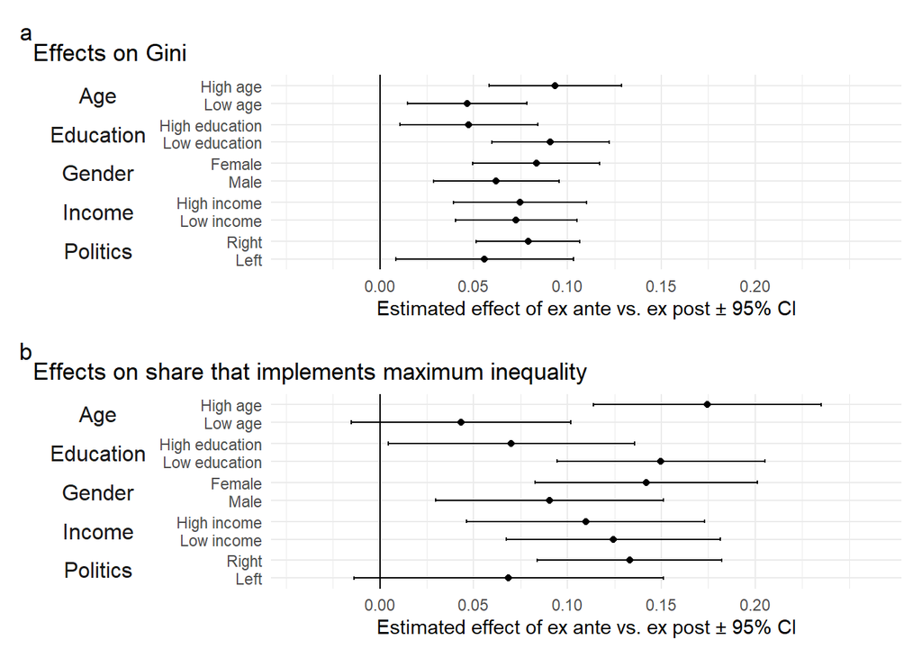

The same heterogeneity figure, but for “personal” (for appendix).

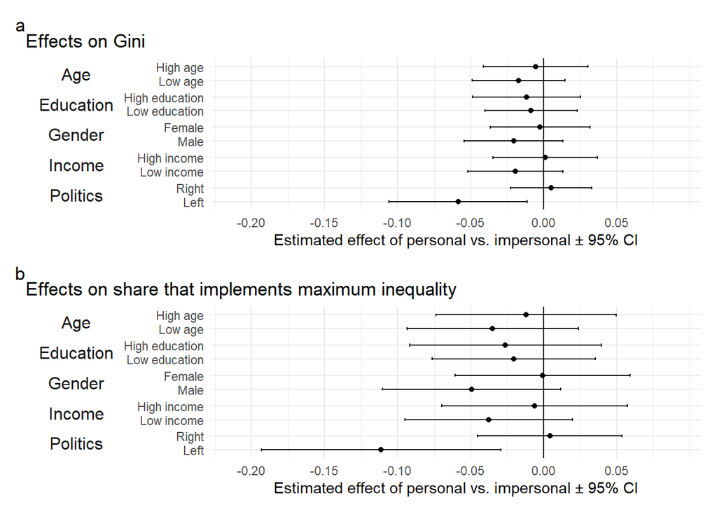

```r
L$graph3 / L$graph4 + plot_annotation(tag_levels = "a") + plot_layout(nrow=2)
```

```r
ggsave(here::here("figures","experiment_heterogeneity_personal.pdf"), width = 16, height=14, units="cm")
```

# Request by referee

A referee wants more details, effects on each level of transfer I propose a solution in which the outcome is the amount given to the disadvantaged, and it varies from no redistribution ($Y=2$), to complete reversal ($Y=8$).

|  | A is favored Yb=2 (1) | A is favored Yb=3 (2) | A is favored Yb=4 (3) | Equality Yb=5 (4) | B is favored Yb=6 (5) | B is favored Yb=7 (6) | B is favored Yb=8 (7) |
| --- | --- | --- | --- | --- | --- | --- | --- |
| Ex Ante Personal (d) | 0.106*** | 0.001 | 0.020 | -0.119*** | -0.002 | 0.001 | -0.006 |
|  | (0.030) | (0.015) | (0.018) | (0.031) | (0.010) | (0.007) | (0.013) |
| Ex Ante Impersonal (d) | 0.143*** | 0.015 | 0.001 | -0.147*** | -0.000 | -0.002 | -0.010 |
|  | (0.030) | (0.015) | (0.018) | (0.031) | (0.010) | (0.007) | (0.013) |
| Ex Post Personal (d) | -0.008 | -0.001 | 0.024 | -0.014 | -0.005 | 0.004 | 0.000 |
|  | (0.029) | (0.014) | (0.017) | (0.031) | (0.010) | (0.007) | (0.013) |
| High age (d) | 0.074*** | -0.038*** | -0.072*** | 0.111*** | -0.040*** | -0.016*** | -0.020** |
|  | (0.021) | (0.010) | (0.013) | (0.022) | (0.007) | (0.005) | (0.009) |
| Left (d) | -0.076*** | 0.013 | 0.009 | 0.073*** | -0.006 | 0.003 | -0.016 |
|  | (0.025) | (0.012) | (0.015) | (0.026) | (0.008) | (0.006) | (0.011) |
| High income (d) | 0.053** | -0.012 | -0.019 | -0.032 | 0.010 | 0.008 | -0.008 |
|  | (0.023) | (0.011) | (0.014) | (0.024) | (0.008) | (0.005) | (0.010) |
| High education (d) | -0.032 | -0.003 | 0.026* | 0.017 | 0.006 | 0.007 | -0.022** |
|  | (0.023) | (0.012) | (0.014) | (0.024) | (0.008) | (0.006) | (0.010) |
| Male (d) | 0.011 | 0.013 | 0.039*** | -0.071*** | 0.006 | -0.004 | 0.005 |
|  | (0.021) | (0.010) | (0.013) | (0.022) | (0.007) | (0.005) | (0.009) |
| (Intercept) | 0.243*** | 0.071*** | 0.093*** | 0.467*** | 0.041*** | 0.015** | 0.071*** |
|  | (0.029) | (0.014) | (0.017) | (0.030) | (0.010) | (0.007) | (0.012) |
| Num.Obs. | 2001 | 2001 | 2001 | 2001 | 2001 | 2001 | 2001 |
| R2 | 0.033 | 0.009 | 0.027 | 0.039 | 0.019 | 0.009 | 0.008 |

* p < 0.1, ** p < 0.05, *** p < 0.01

We compare the transfers in our experiment with those in the *“Cuddly Socialism”* study (Almås et al., *Journal of Political Economy*, 2020). The most comparable treatments are the **Luck** treatment in Almås et al., which corresponds most closely to the **Ex Post Impersonal** treatment in the current study. The range of possible allocations differs slightly across the two settings. In our study, allocations range from **(8, 2)** to **(2, 8)**, while in the Almås et al. study the range is **(6, 0)** to **(0, 6)**. Thus, the range of the *transfer* variable is identical across studies. Because the data from Almås et al. do not include post-stratification weights, we base the comparison on **unweighted** shares.

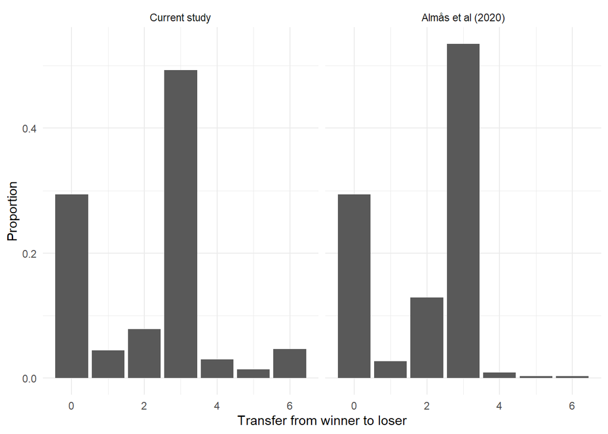

*Note:* For the current study, the figure shows the distribution of transfers in the **Ex Post Impersonal** treatment. For the Almås et al. (2020) study, it shows the distribution of transfers in the United States in the **Luck** treatment.

The estimated proportions are:

Proportion of transfer values by study

| transfer | Current study | Almås et al (2020) |
| --- | --- | --- |
| 0 | 0.294 (0.020) | 0.294 (0.025) |
| 1 | 0.044 (0.009) | 0.027 (0.009) |
| 2 | 0.078 (0.012) | 0.129 (0.018) |
| 3 | 0.493 (0.022) | 0.535 (0.027) |
| 4 | 0.030 (0.008) | 0.009 (0.005) |
| 5 | 0.014 (0.005) | 0.003 (0.003) |
| 6 | 0.046 (0.009) | 0.003 (0.003) |